# Producción_de_bananas_dulces

Priscilla Castro Blanco

2024-08-31

Instalación de paquetes

```r
#install.packages("dplyr")
library("dplyr")
```

```r
library("ggplot2")
```

```r
#install.packages("corrplot")
library("corrplot")
#install.packages("magrittr")
library("magrittr")
```

```r
#install.packages("skimr")
#library("skimr")
```

# Análisis para determinar maneras de incrementar la dulzura en las bananas

### Objetivo

Para este proyecto de análisis de datos, analicé las variables que se correlacionan con el “dulzor” de los bananos cosechados, con la intención de encontrar datos para mejorar la producción de bananos con mayor dulzor y, de ser posible, en un menor tiempo.

# 1. Ingestión de datos

Seleccionamos los datos a utilizar y realizamos su correcta ingestión.

```r
banana <- read.csv('banana_quality.csv')

head(banana)
```

```
##         Size    Weight   Sweetness  Softness HarvestTime Ripeness   Acidity
## 1 -1.9249682 0.4680781  3.07783250 -1.472177   0.2947986 2.435570 0.2712903
## 2 -2.4097514 0.4868699  0.34692144 -2.495099  -0.8922133 2.067549 0.3073251
## 3 -0.3576066 1.4831762  1.56845220 -2.645145  -0.6472673 3.090643 1.4273220
## 4 -0.8685235 1.5662014  1.88960490 -1.273761  -1.0062776 1.873001 0.4778617
## 5  0.6518253 1.3191992 -0.02245899 -1.209709  -1.4306920 1.078345 2.8124418
## 6 -2.8077223 1.1381357  3.44762680 -1.713302  -2.2209115 2.079410 2.2812028
##   Quality
## 1    Good
## 2    Good
## 3    Good
## 4    Good
## 5    Good
## 6    Good
```

Podemos observar que existen 8 variables distintas en este set de datos. Variables como el tamaño, el peso, la dulzura (que es la variable que queremos mejorar), la suavidad, el tiempo de cosecha, la madurez, la acidez y la calidad.

Antes de realizar los análisis de distribución, nos aseguramos que estamos trabajando con un “data frame”.

```r
print(class(banana))
```

```
## [1] "data.frame"
```

# 2. Análisis de Distribución.

A continuación vamos a analizar la distribución de los datos. Lo haremos al realizar histogramas y al evaluar la normalidad de las variables numéricas en el conjunto de dato y su distribución a través d la prueba shapiro.

```r
set.seed(10)
banana_norm <- rnorm(100) # Creamos una variable normal con 100 valores
banana.test <- shapiro.test(banana_norm)
print(banana.test)
```

```
##
##  Shapiro-Wilk normality test
##
## data:  banana_norm
## W = 0.98908, p-value = 0.5911
```

Obtenemos una p > 0.05, lo que significa que existe una distribución normal para los datos aleatorios escogidos.

```r
banana2 <- runif(100) # Creamos una variable con distribución uniforme (no normal) con 100 valores
banana2.test <- shapiro.test(banana2)
print(banana2.test)
```

```
##
##  Shapiro-Wilk normality test
##
## data:  banana2
## W = 0.92848, p-value = 4.082e-05
```

p < 0.05 → Distribución no normal, como es de esperarse, para los valores escogidos con distribución uniforme.

Para esto decidimos tomar las variables: “Sweetness”, “Size”, “Weight”, “Softness”, “HarvestTime” y “Ripeness”.

Para estas variables después de observar su normalidad a través de histogramas, determinaremos la correlación entre sí con una prueba de Pearson, con la finalidad de observar si es posible encontrar en dónde podemos realizar cambios al sistema de producción para producir bananas más dulces.

### Creación de los histogramas

```r
names(banana)
```

```
## [1] "Size"        "Weight"      "Sweetness"   "Softness"    "HarvestTime"
## [6] "Ripeness"    "Acidity"     "Quality"
```

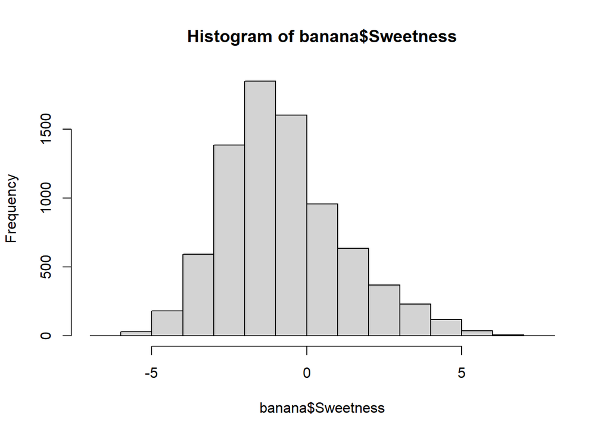

```r
hist(banana$Sweetness)
```

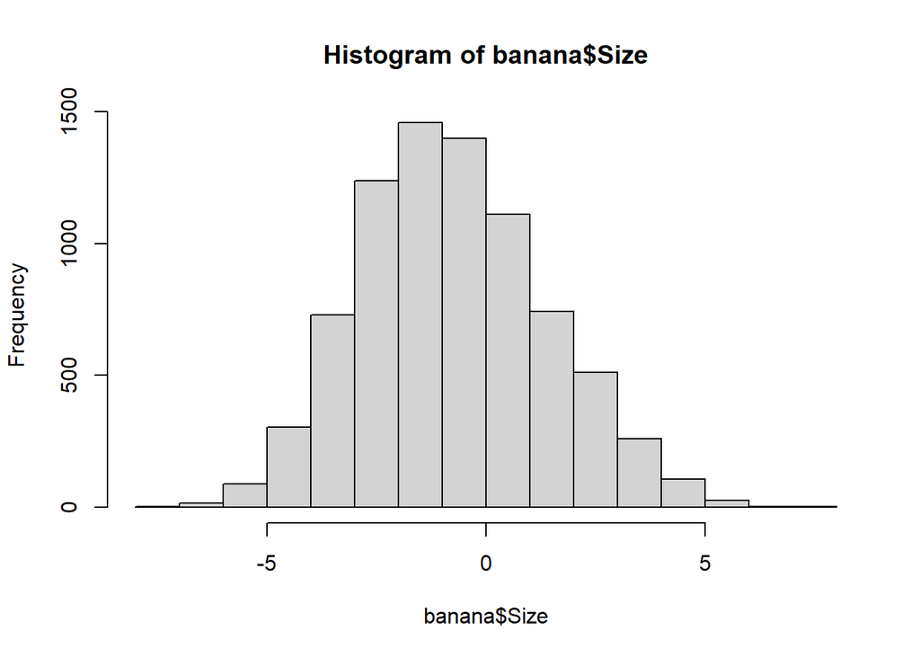

```r
hist(banana$Size)
```

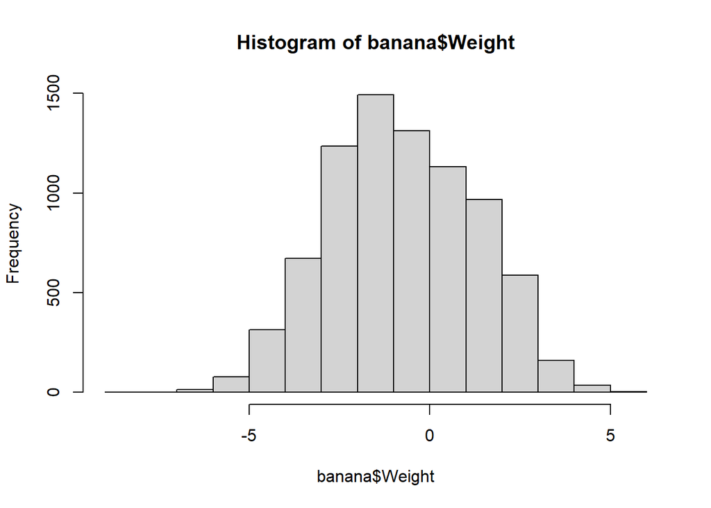

```r
hist(banana$Weight)
```

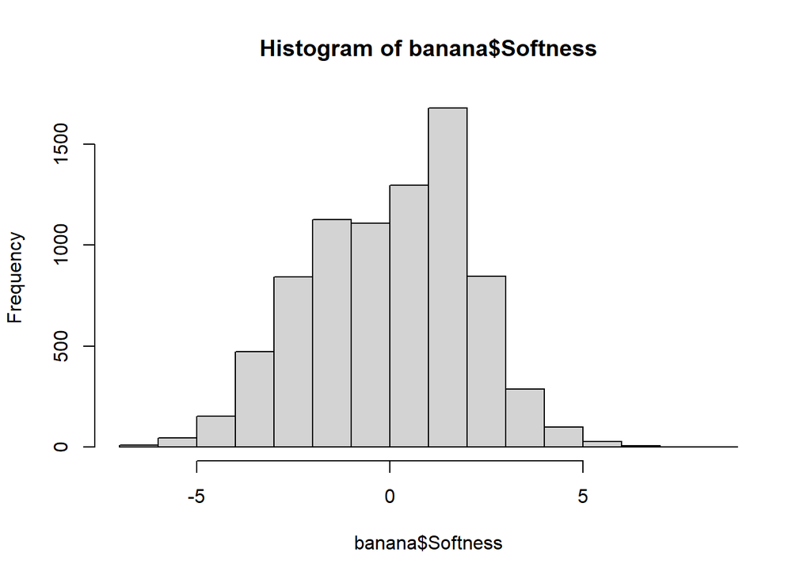

```r
hist(banana$Softness)
```

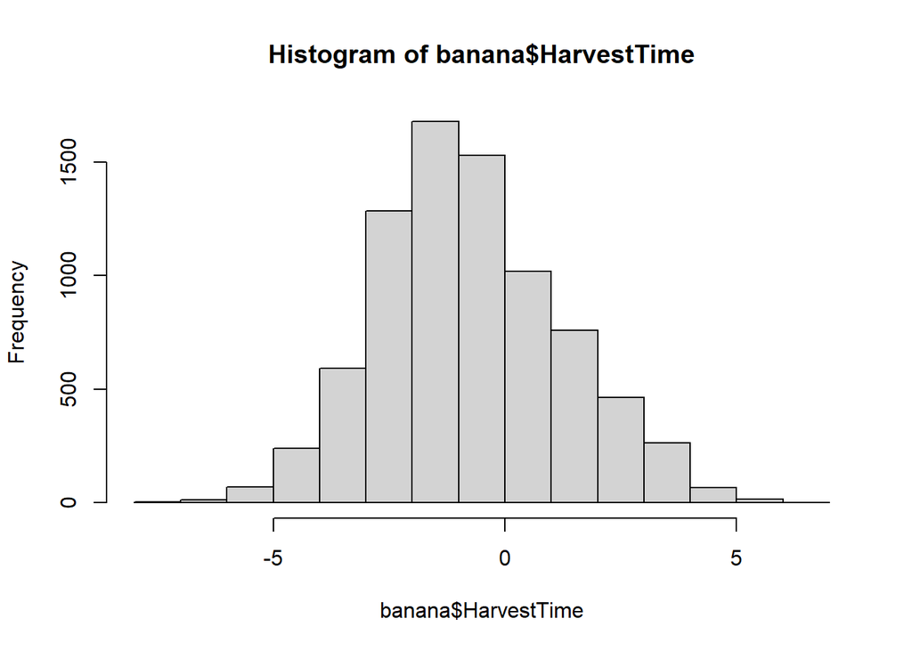

```r
hist(banana$HarvestTime)
```

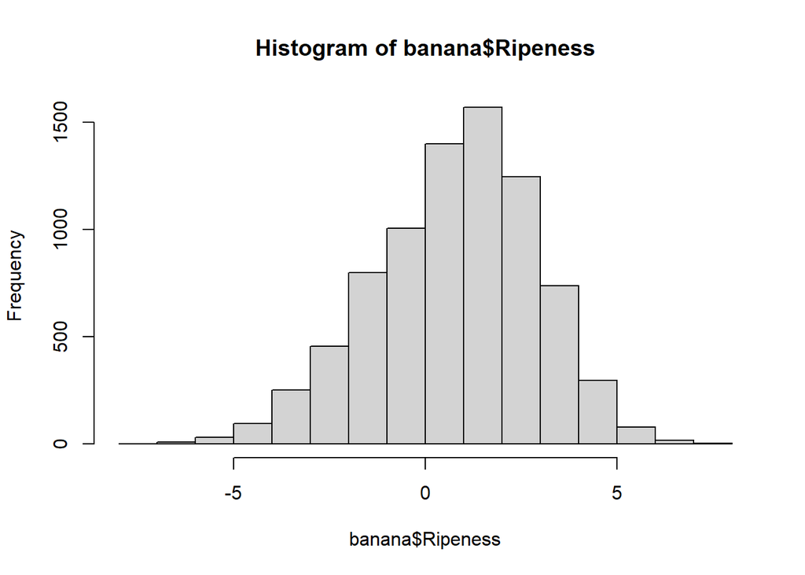

```r
hist(banana$Ripeness)
```

### Observaciones.

Se puede observar que para los 6 histogramas generados, existe una distribución normal de los valores entre -5 y 5 en la frecuencia. De esta manera sabemos que los podemos relacionar entre sí al realizar una prueba de pearson.

# 3. Correlación de Variables:

Calculamos seguidamente la correlación entre las variables y observamos la naturaleza de esta correlación. El objetivo es seleccionar las variables que presenten una correlación significativa con la variable objetivo (dulzura de la banana).

```r
data_numerica <- banana %>% select_if(is.numeric)
correlacion <- cor(data_numerica, method = "pearson")
correlacion
```

```
##                    Size      Weight   Sweetness    Softness HarvestTime
## Size         1.00000000 -0.18193333 -0.25802659  0.16452633  0.58201410
## Weight      -0.18193333  1.00000000  0.42268321 -0.18990848 -0.07946457
## Sweetness   -0.25802659  0.42268321  1.00000000 -0.09533752 -0.20165705
## Softness     0.16452633 -0.18990848 -0.09533752  1.00000000  0.19473352
## HarvestTime  0.58201410 -0.07946457 -0.20165705  0.19473352  1.00000000
## Ripeness     0.04258715 -0.03527563  0.18009520 -0.25380431  0.10712724
## Acidity     -0.14067322  0.44387916  0.18705898 -0.14601390 -0.09090289
##                Ripeness     Acidity
## Size         0.04258715 -0.14067322
## Weight      -0.03527563  0.44387916
## Sweetness    0.18009520  0.18705898
## Softness    -0.25380431 -0.14601390
## HarvestTime  0.10712724 -0.09090289
## Ripeness     1.00000000 -0.35153130
## Acidity     -0.35153130  1.00000000
```

Ahoragraficamos la correlación que nos permite observar de manera más fácil las correlaciones entre las variables.

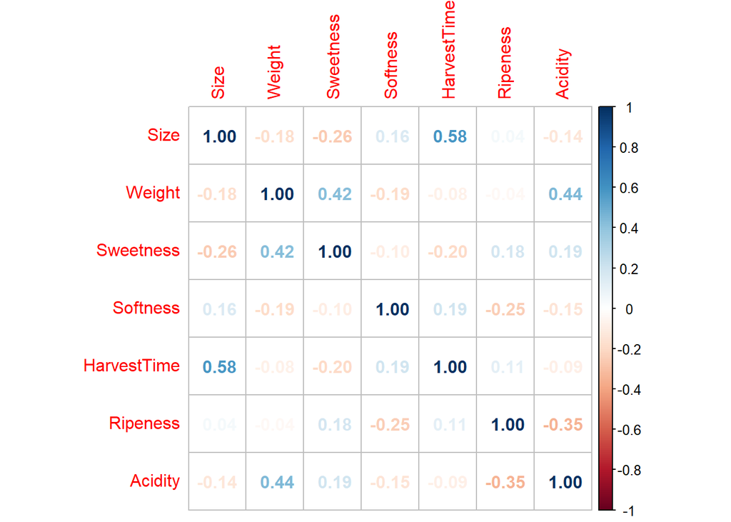

```r
cor.data <- round(cor(data_numerica), 2)
corrplot(cor.data, method="number")
```

Si tomamos en cuenta que → 1 significa correlación positiva perfecta → -1 significa correlación negativa perfecta → 0 sugnifica ausencia de correlación lineal entre las variables

Podemos observar que 1. Entre el tamaño “Size” y el tiempo de cosecha “HarvestTime” existe una correlación positiva, sugieriendo que entre mayor tiempo de cosecha, mayor será el tamaño. Esto tiene sentido ya que si se deja el cultivo por mayor tiempo, se podría esperar que este crezca más durante ese tiempo extra, hasta llegar a su tamaño máximo.

**Otras correlaciones observadas.**

Cabe destacar que la correlación no implica causalidad y existen muchos otros factores que no estamos tomando en cuenta. Para determinar si existe alguna correlación y causalidad para algún conjunto específico, se debe corroborar con experimentos e hipótesis.

# 4.Interpretación de los resultados:

Para esta parte, podemos observar que las variables de “Sweetness”, “Size”, “Weight”, “Softness”, “HarvestTime” y “Ripeness” poseen una distribución normal. Además, al realizar la prueba de Pearson, observamos que la dulzura de la fruta “Sweetness” posee una correlación positiva (hasta cierto punto) con su peso “Weight”, por lo que se observarán a fondo estos datos para determinar si deben ser corregidos de alguna manera, y sacar posibles conclusiones de cómo se puede mejorar el proceso para aumentar la dulzura de las bananas producidas.

```r
summary(banana)
```

```
##       Size             Weight          Sweetness          Softness
##  Min.   :-7.9981   Min.   :-8.2830   Min.   :-6.4340   Min.   :-6.95932
##  1st Qu.:-2.2777   1st Qu.:-2.2236   1st Qu.:-2.1073   1st Qu.:-1.59046
##  Median :-0.8975   Median :-0.8687   Median :-1.0207   Median : 0.20264
##  Mean   :-0.7478   Mean   :-0.7610   Mean   :-0.7702   Mean   :-0.01444
##  3rd Qu.: 0.6542   3rd Qu.: 0.7755   3rd Qu.: 0.3110   3rd Qu.: 1.54712
##  Max.   : 7.9708   Max.   : 5.6797   Max.   : 7.5394   Max.   : 8.24155
##   HarvestTime         Ripeness          Acidity            Quality
##  Min.   :-7.5700   Min.   :-7.4232   Min.   :-8.226977   Length:8000
##  1st Qu.:-2.1207   1st Qu.:-0.5742   1st Qu.:-1.629450   Class :character
##  Median :-0.9342   Median : 0.9650   Median : 0.098735   Mode  :character
##  Mean   :-0.7513   Mean   : 0.7811   Mean   : 0.008725
##  3rd Qu.: 0.5073   3rd Qu.: 2.2616   3rd Qu.: 1.682063
##  Max.   : 6.2933   Max.   : 7.2490   Max.   : 7.411633
```

Según hemos visto en el cuadro de correlación con el método de Pearson, la dulzura de la banana podría estar relacionada hasta cierto punto con su peso, por lo que observaremos los datos estadísticos de estas dos variables, y determinaremos si es necesario limitar la cantidad de datos por ejemplo, para obtener una correlación más alta.

#### Datos estadísticos de “Sweetness”.

```r
summary(banana$Sweetness)
```

```
##    Min. 1st Qu.  Median    Mean 3rd Qu.    Max.
## -6.4340 -2.1073 -1.0207 -0.7702  0.3110  7.5394
```

```r
var(banana$Sweetness)
```

```
## [1] 3.796476
```

Se observa que el dato máximo es de 7.5394, y el tercer cuartil empieza en el dato 0.3110, por lo que existe gran diferencia. Además, su varianza es de 3.8, lo que denota que los datos no están tan lejanos entre sí, pero tampoco tan cerca, por lo que se limitarán los datos hasta el tercer cuartil buscando mejorar la varianza y la muestra de datos que se posee.

#### Datos estadísticos de “Weight”.

```r
summary(banana$Weight)
```

```
##    Min. 1st Qu.  Median    Mean 3rd Qu.    Max.
## -8.2830 -2.2236 -0.8687 -0.7610  0.7755  5.6797
```

```r
var(banana$Weight)
```

```
## [1] 4.063991
```

Como se observa, nuevamente el máximo (5.6797) está lejos del tercer cuartil (0.7755) y además la varianza es de 4.0 lo que indica que los datos no están muy dispersos, pero tampoco están muy agrupados cerca de la media.Por esta razón se limitará este set de datos de igual manera al tercer cuartil.

## 5 Selección de Variables Relevantes:

Se realiza la selección por cuantiles para ambas variables, con el eobjetivo de obtener un dataset más limpio y relevante.

```r
# Calcular el cuantil del 75% y 25% para Sweetness
cuantil_sweetness1 <- quantile(banana$Sweetness, 0.25)
cuantil_sweetness2 <- quantile(banana$Sweetness, 0.75)

# Filtrar los datos por debajo del cuantil del 75%
datos_filtrados_sweet <- banana$Sweetness[cuantil_sweetness1 < banana$Sweetness & banana$Sweetness < cuantil_sweetness2]

# Obtener el summary de los datos filtrados
summary(datos_filtrados_sweet)
```

```
##    Min. 1st Qu.  Median    Mean 3rd Qu.    Max.
## -2.1072 -1.5475 -1.0207 -0.9885 -0.4493  0.3107
```

```r
var_cuantil_sweet <- var(datos_filtrados_sweet)
var_cuantil_sweet
```

```
## [1] 0.4429681
```

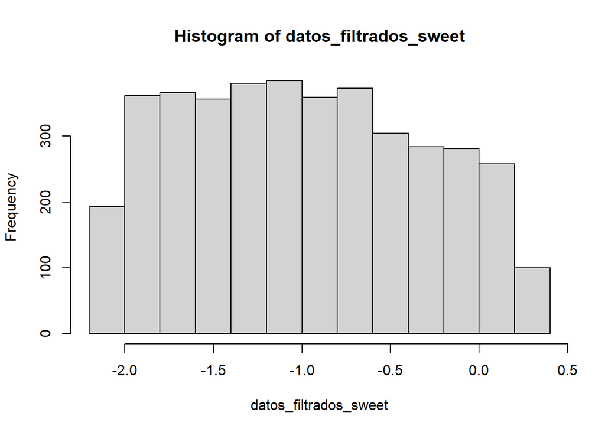

```r
hist(datos_filtrados_sweet)
```

De esta manera la varianza es ahora de 0.4 por lo que los datos se encuentran mucho mas cerca entre si.

Realizamos lo mismo para “Weight” esperando obtener un resultado similar.

```r
# Calcular el cuantil del 75% para Weight
cuantil_weight1 <- quantile(banana$Weight, 0.25)
cuantil_weight2 <- quantile(banana$Weight, 0.75)

# Filtrar los datos por debajo del cuantil del 75%
datos_filtrados_weight <- banana$Weight[cuantil_weight1 < banana$Weight & banana$Weight < cuantil_weight2]

# Obtener el summary de los datos filtrados
summary(datos_filtrados_weight)
```

```
##     Min.  1st Qu.   Median     Mean  3rd Qu.     Max.
## -2.22300 -1.53262 -0.86866 -0.81218 -0.09764  0.77532
```

```r
var_cuantil_75ht <- var(datos_filtrados_weight)
var_cuantil_75ht
```

```
## [1] 0.7219375
```

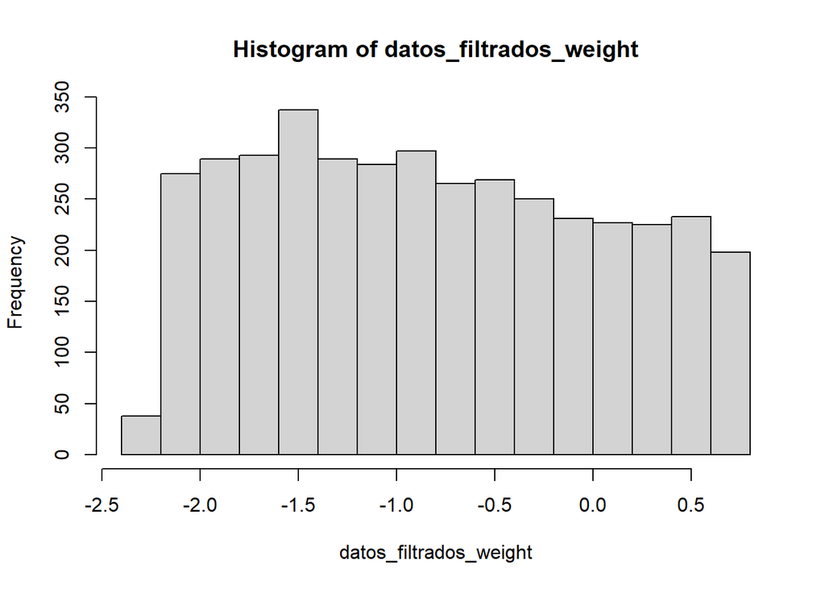

```r
hist(datos_filtrados_weight)
```

Por lo tanto, se observa que efectivamente de esta manera la varianza denota una mayor cercania entre los datos.

Ahora realizaremos un gráfico de dispersión con los datos filtrados y no filtrados de “Weight” y de “Sweetness”, para verificar la relación existente entre estas variables.

### Datos no filtrados

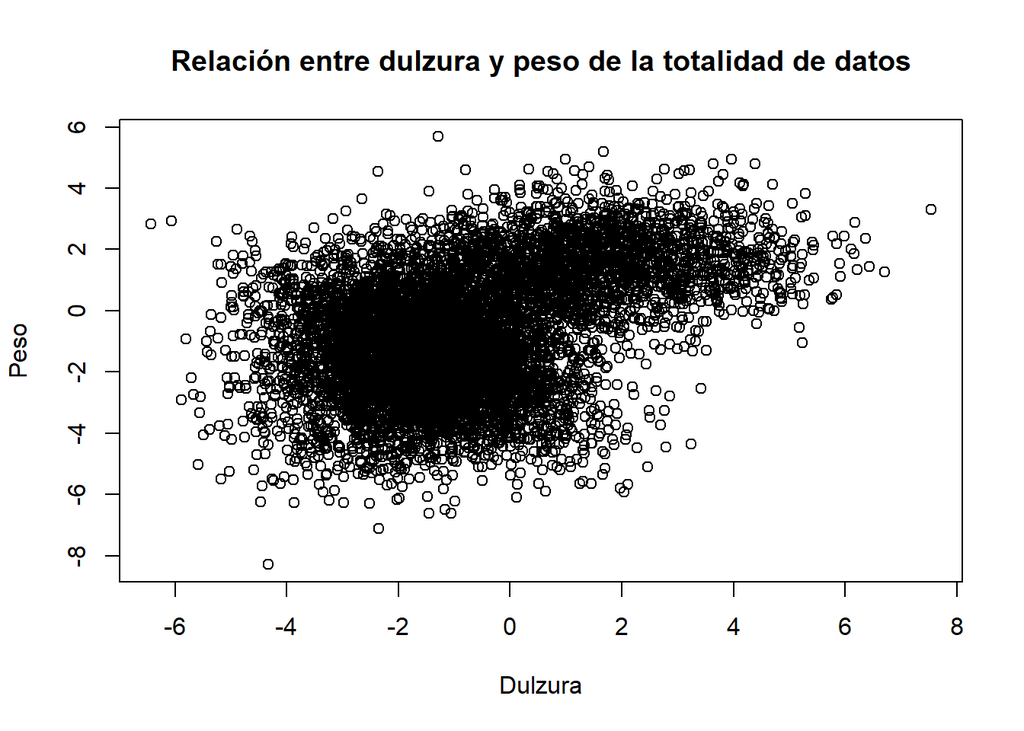

```r
plot(banana$Sweetness, banana$Weight, xlab="Dulzura", ylab="Peso", main="Relación entre dulzura y peso de la totalidad de datos")
```

### Datos filtrados

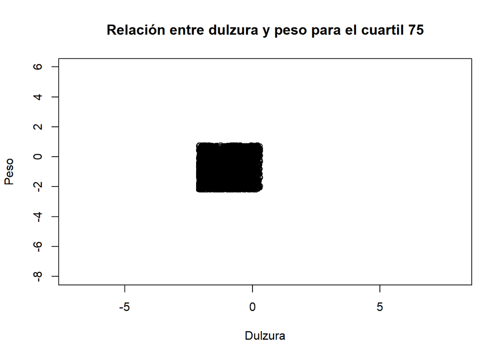

```r
x_min <- -7
x_max <- 8
y_min <- -8
y_max <- 6


plot(datos_filtrados_sweet, datos_filtrados_weight, xlab="Dulzura", ylab="Peso", main="Relación entre dulzura y peso para el cuartil 75", xlim = c(x_min, x_max), ylim = c(y_min, y_max))
```

# 6 Conclusiones:

1. Existe una correlación media entre la dulzura y el peso de la fruta de un 0.42, lo que sugiere que se puede indicar hasta cierto punto la dulzura que la fruta obtendrá según su peso.
2. No existe otra variable aparte del peso que posea una relación significativa con la dulzura (variable objetivo) de la fruta según el método de Pearson.
3. Aunque existe correlación media entre la dulzura y el peso de la banana, esto no necesariamente significa causalidad, por lo que se debe explorar más a fondo esta correlación. Por esta razón se recomienda desarrollar experimentos de procesos para cambiar el peso de la fruta y de esta manera determinar si se generan los cambios deseados en la dulzura de la fruta.